# Practical Machine Learning - Predictions Assignment

Xiaoran Guo

September 23, 2018

## General Assignment Information

### Background

Using devices such as Jawbone Up, Nike FuelBand, and Fitbit it is now possible to collect a large amount of data about personal activity relatively inexpensively. These type of devices are part of the quantified self movement – a group of enthusiasts who take measurements about themselves regularly to improve their health, to find patterns in their behavior, or because they are tech geeks. One thing that people regularly do is quantify how much of a particular activity they do, but they rarely quantify how well they do it. In this project, your goal will be to use data from accelerometers on the belt, forearm, arm, and dumbell of 6 participants. They were asked to perform barbell lifts correctly and incorrectly in 5 different ways. More information is available from the website here: http://web.archive.org/web/20161224072740/http:/groupware.les.inf.puc-rio.br/har (see the section on the Weight Lifting Exercise Dataset).

### Data

The training data for this project are available here:

https://d396qusza40orc.cloudfront.net/predmachlearn/pml-training.csv

The test data are available here:

https://d396qusza40orc.cloudfront.net/predmachlearn/pml-testing.csv

The data for this project come from this source: http://web.archive.org/web/20161224072740/http:/groupware.les.inf.puc-rio.br/har. If you use the document you create for this class for any purpose please cite them as they have been very generous in allowing their data to be used for this kind of assignment.

### Full citation

Velloso, E.; Bulling, A.; Gellersen, H.; Ugulino, W.; Fuks, H. Qualitative Activity Recognition of Weight Lifting Exercises. Proceedings of 4th International Conference in Cooperation with SIGCHI (Augmented Human ’13) . Stuttgart, Germany: ACM SIGCHI, 2013.

## The Assignment

### Loading the Data

```r
library(caret)
library(randomForest)
library(e1071)
library(party)
```

```r
train_raw <- read.csv(url("https://d396qusza40orc.cloudfront.net/predmachlearn/pml-training.csv"))
test_raw <- read.csv(url("https://d396qusza40orc.cloudfront.net/predmachlearn/pml-testing.csv"))
```

### Cleaning the Data (removing NAs and empty columns)

```r
colSums(is.na(train_raw))
```

```
##                    X            user_name raw_timestamp_part_1
##                    0                    0                    0
## raw_timestamp_part_2       cvtd_timestamp           new_window
##                    0                    0                    0
##           num_window            roll_belt           pitch_belt
##                    0                    0                    0
##             yaw_belt     total_accel_belt   kurtosis_roll_belt
##                    0                    0                    0
##  kurtosis_picth_belt    kurtosis_yaw_belt   skewness_roll_belt
##                    0                    0                    0
## skewness_roll_belt.1    skewness_yaw_belt        max_roll_belt
##                    0                    0                19216
##       max_picth_belt         max_yaw_belt
##                19216                    0
##  [ reached getOption("max.print") -- omitted 140 entries ]
```

```r
colSums(is.na(test_raw))
```

```
##                    X            user_name raw_timestamp_part_1
##                    0                    0                    0
## raw_timestamp_part_2       cvtd_timestamp           new_window
##                    0                    0                    0
##           num_window            roll_belt           pitch_belt
##                    0                    0                    0
##             yaw_belt     total_accel_belt   kurtosis_roll_belt
##                    0                    0                   20
##  kurtosis_picth_belt    kurtosis_yaw_belt   skewness_roll_belt
##                   20                   20                   20
## skewness_roll_belt.1    skewness_yaw_belt        max_roll_belt
##                   20                   20                   20
##       max_picth_belt         max_yaw_belt
##                   20                   20
##  [ reached getOption("max.print") -- omitted 140 entries ]
```

Many columns contain no NAs. Other columns consistently have 19216 of 19622 entries as NAs. These columns should be excluded from the analysis as the vast majority of them are blank and the testing data set has the same columns empty in 20 of 20 entries. In addition, columns 1 through 7 in both training and testing contained participant identification information or metadata. These are also removed.

```r
train_raw[train_raw==""] <- NA #set blank entries as NA
train <- train_raw[, apply(train_raw, 2, function(x) !any(is.na(x)))] #remove any columns with NAs
train <- train[, -c(1:7)] #remove first 7 columns

test <- test_raw[, apply(test_raw, 2, function(x) !any(is.na(x)))]  #remove any columns with NAs
test <- test[, -c(1:7)] #remove first 7 columns
```

### Prediction Goal

From the original paper:

“Six young health participants were asked to perform one set of 10 repetitions of the Unilateral Dumbbell Biceps Curl in five different fashions:

- exactly according to the specification (Class A)
- throwing the elbows to the front (Class B)
- lifting the dumbbell only halfway (Class C)
- lowering the dumbbell only halfway (Class D) and
- throwing the hips to the front (Class E)"

### Cross-Validation

A 0.75/0.25 split will be used for training data to explore three models.

```r
set.seed(10000)
inTrain <- createDataPartition(y=train$classe, p=0.75,list=FALSE)
training <- train[inTrain,]
testing <- train[-inTrain,]
```

### The Models

#### Predicting with Trees Model

```r
# Training
modelTrees <- train(classe~.,method="rpart",data=training)
confusionMatrix(training$classe,predict(modelTrees))
```

```
## Confusion Matrix and Statistics
##
##           Reference
## Prediction    A    B    C    D    E
##          A 3807   64  302    0   12
##          B 1203  952  693    0    0
##          C 1180   82 1305    0    0
##          D 1101  407  904    0    0
##          E  390  368  714    0 1234
##
## Overall Statistics
##
##                Accuracy : 0.4959
##                  95% CI : (0.4877, 0.504)
##     No Information Rate : 0.5219
##     P-Value [Acc > NIR] : 1
##
##                   Kappa : 0.341
##  Mcnemar's Test P-Value : NA
##
## Statistics by Class:
##
##                      Class: A Class: B Class: C Class: D Class: E
## Sensitivity            0.4956  0.50828  0.33308       NA  0.99037
## Specificity            0.9463  0.85239  0.88315   0.8361  0.89074
## Pos Pred Value         0.9097  0.33427  0.50838       NA  0.45602
## Neg Pred Value         0.6322  0.92241  0.78496       NA  0.99900
## Prevalence             0.5219  0.12726  0.26620   0.0000  0.08466
## Detection Rate         0.2587  0.06468  0.08867   0.0000  0.08384
## Detection Prevalence   0.2843  0.19350  0.17441   0.1639  0.18386
## Balanced Accuracy      0.7210  0.68033  0.60811       NA  0.94055
```

```r
# OOS Validating
Trees <- predict(modelTrees,newdata=testing)
confusionMatrix(testing$classe,Trees)
```

```
## Confusion Matrix and Statistics
##
##           Reference
## Prediction    A    B    C    D    E
##          A 1273   17  103    0    2
##          B  378  334  237    0    0
##          C  407   26  422    0    0
##          D  348  161  295    0    0
##          E  134  118  252    0  397
##
## Overall Statistics
##
##                Accuracy : 0.4947
##                  95% CI : (0.4806, 0.5088)
##     No Information Rate : 0.5179
##     P-Value [Acc > NIR] : 0.9995
##
##                   Kappa : 0.3397
##  Mcnemar's Test P-Value : NA
##
## Statistics by Class:
##
##                      Class: A Class: B Class: C Class: D Class: E
## Sensitivity            0.5012  0.50915  0.32238       NA  0.99499
## Specificity            0.9484  0.85523  0.87955   0.8361  0.88812
## Pos Pred Value         0.9125  0.35195  0.49357       NA  0.44062
## Neg Pred Value         0.6389  0.91858  0.78093       NA  0.99950
## Prevalence             0.5179  0.13377  0.26692   0.0000  0.08136
## Detection Rate         0.2596  0.06811  0.08605   0.0000  0.08095
## Detection Prevalence   0.2845  0.19352  0.17435   0.1639  0.18373
## Balanced Accuracy      0.7248  0.68219  0.60097       NA  0.94156
```

The Predict with Trees model shows an in-sample prediction accuracy of 49.6%, and an out-of-sample prediction accuracy of 49.5%. This is not very good and is no better than a random guess.

#### Support Vector Machine Model

```r
# Training
modelSVM <- svm(training[,-53],training$classe) #Support Vector Machine model
confusionMatrix(training$classe,predict(modelSVM))
```

```
## Confusion Matrix and Statistics
##
##           Reference
## Prediction    A    B    C    D    E
##          A 4174    3    7    0    1
##          B  205 2587   50    2    4
##          C    6   62 2481   17    1
##          D    4    0  231 2176    1
##          E    0   11   68   58 2569
##
## Overall Statistics
##
##                Accuracy : 0.9503
##                  95% CI : (0.9467, 0.9538)
##     No Information Rate : 0.2982
##     P-Value [Acc > NIR] : < 2.2e-16
##
##                   Kappa : 0.9371
##  Mcnemar's Test P-Value : < 2.2e-16
##
## Statistics by Class:
##
##                      Class: A Class: B Class: C Class: D Class: E
## Sensitivity            0.9510   0.9715   0.8745   0.9658   0.9973
## Specificity            0.9989   0.9783   0.9928   0.9811   0.9887
## Pos Pred Value         0.9974   0.9084   0.9665   0.9022   0.9494
## Neg Pred Value         0.9796   0.9936   0.9707   0.9937   0.9994
## Prevalence             0.2982   0.1809   0.1928   0.1531   0.1750
## Detection Rate         0.2836   0.1758   0.1686   0.1478   0.1745
## Detection Prevalence   0.2843   0.1935   0.1744   0.1639   0.1839
## Balanced Accuracy      0.9750   0.9749   0.9336   0.9734   0.9930
```

```r
# OOS Validating
SVM <- predict(modelSVM,testing[,-53])
confusionMatrix(testing$classe,SVM)
```

```
## Confusion Matrix and Statistics
##
##           Reference
## Prediction    A    B    C    D    E
##          A 1390    2    3    0    0
##          B   63  852   31    0    3
##          C    1   34  814    6    0
##          D    2    0   77  725    0
##          E    0   10   34   14  843
##
## Overall Statistics
##
##                Accuracy : 0.9429
##                  95% CI : (0.936, 0.9492)
##     No Information Rate : 0.2969
##     P-Value [Acc > NIR] : < 2.2e-16
##
##                   Kappa : 0.9277
##  Mcnemar's Test P-Value : NA
##
## Statistics by Class:
##
##                      Class: A Class: B Class: C Class: D Class: E
## Sensitivity            0.9547   0.9488   0.8488   0.9732   0.9965
## Specificity            0.9985   0.9758   0.9896   0.9810   0.9857
## Pos Pred Value         0.9964   0.8978   0.9520   0.9017   0.9356
## Neg Pred Value         0.9812   0.9884   0.9642   0.9951   0.9993
## Prevalence             0.2969   0.1831   0.1956   0.1519   0.1725
## Detection Rate         0.2834   0.1737   0.1660   0.1478   0.1719
## Detection Prevalence   0.2845   0.1935   0.1743   0.1639   0.1837
## Balanced Accuracy      0.9766   0.9623   0.9192   0.9771   0.9911
```

The SVM model shows an in-sample prediction accuracy of 95.0%, and an out-of-sample accuracy of 94.3%. This is much better and appears to be fairly robust.

#### Random Forest Model

```r
# Training
modelRF <- randomForest(classe ~ ., data=training) #Random Forest model
confusionMatrix(training$classe,predict(modelRF))
```

```
## Confusion Matrix and Statistics
##
##           Reference
## Prediction    A    B    C    D    E
##          A 4180    4    1    0    0
##          B   10 2831    7    0    0
##          C    0   12 2553    2    0
##          D    0    0   26 2385    1
##          E    0    0    2    6 2698
##
## Overall Statistics
##
##                Accuracy : 0.9952
##                  95% CI : (0.9939, 0.9962)
##     No Information Rate : 0.2847
##     P-Value [Acc > NIR] : < 2.2e-16
##
##                   Kappa : 0.9939
##  Mcnemar's Test P-Value : NA
##
## Statistics by Class:
##
##                      Class: A Class: B Class: C Class: D Class: E
## Sensitivity            0.9976   0.9944   0.9861   0.9967   0.9996
## Specificity            0.9995   0.9986   0.9988   0.9978   0.9993
## Pos Pred Value         0.9988   0.9940   0.9945   0.9888   0.9970
## Neg Pred Value         0.9991   0.9987   0.9970   0.9993   0.9999
## Prevalence             0.2847   0.1934   0.1759   0.1626   0.1834
## Detection Rate         0.2840   0.1923   0.1735   0.1620   0.1833
## Detection Prevalence   0.2843   0.1935   0.1744   0.1639   0.1839
## Balanced Accuracy      0.9986   0.9965   0.9925   0.9972   0.9995
```

```r
# OOS Validating
RF <- predict(modelRF, testing, type="class")
confusionMatrix(testing$classe,RF)
```

```
## Confusion Matrix and Statistics
##
##           Reference
## Prediction    A    B    C    D    E
##          A 1394    1    0    0    0
##          B    2  947    0    0    0
##          C    0    5  850    0    0
##          D    0    0    4  799    1
##          E    0    0    3    4  894
##
## Overall Statistics
##
##                Accuracy : 0.9959
##                  95% CI : (0.9937, 0.9975)
##     No Information Rate : 0.2847
##     P-Value [Acc > NIR] : < 2.2e-16
##
##                   Kappa : 0.9948
##  Mcnemar's Test P-Value : NA
##
## Statistics by Class:
##
##                      Class: A Class: B Class: C Class: D Class: E
## Sensitivity            0.9986   0.9937   0.9918   0.9950   0.9989
## Specificity            0.9997   0.9995   0.9988   0.9988   0.9983
## Pos Pred Value         0.9993   0.9979   0.9942   0.9938   0.9922
## Neg Pred Value         0.9994   0.9985   0.9983   0.9990   0.9998
## Prevalence             0.2847   0.1943   0.1748   0.1637   0.1825
## Detection Rate         0.2843   0.1931   0.1733   0.1629   0.1823
## Detection Prevalence   0.2845   0.1935   0.1743   0.1639   0.1837
## Balanced Accuracy      0.9991   0.9966   0.9953   0.9969   0.9986
```

The Random Forest model shows an in-sample prediction accuracy of 99.5% and an out-of-sample accuracy of 99.6%. This is the best performing model so far, for both in-sample and out-of-sample predictions.

#### Visualizing the Error Rate

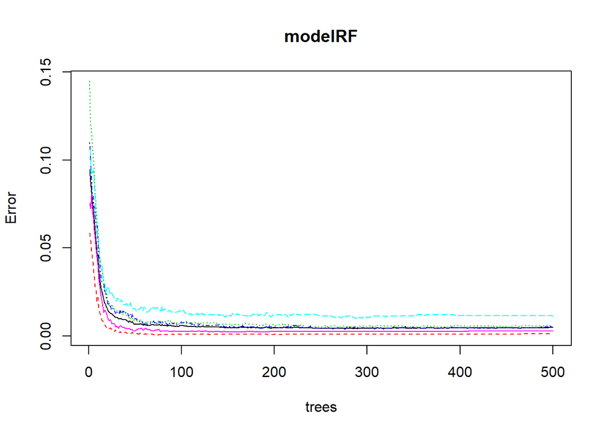

```r
plot(modelRF)
```

The black line represents the out-of-sample error rate. The other colours represent categories A through E.

#### Visualizing a Single Tree

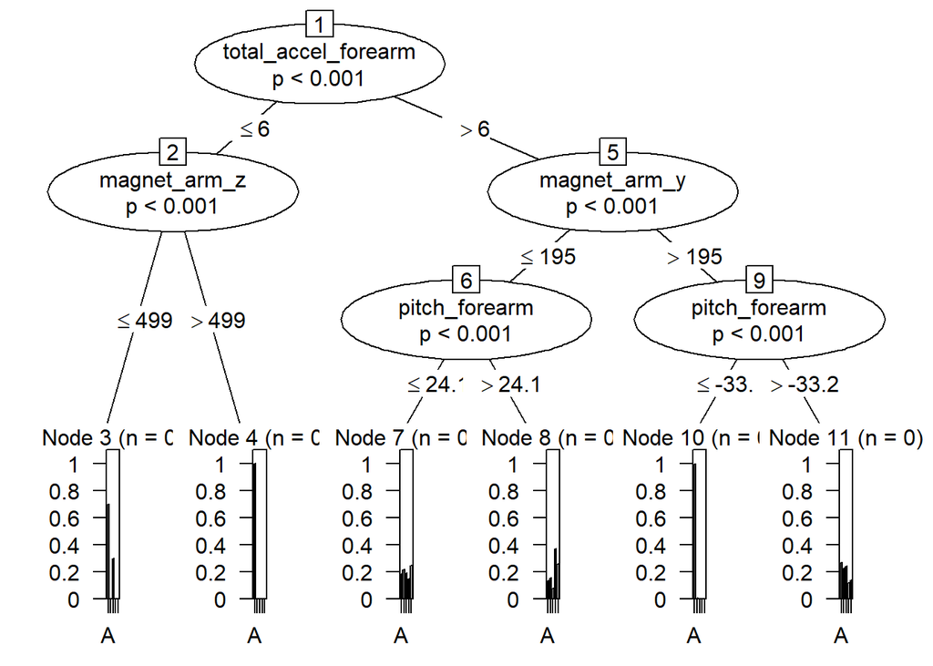

```r
cf <- cforest(classe~.,data=training, controls=cforest_control(maxdepth=3))
pt <- prettytree(cf@ensemble[[1]], names(cf@data@get("input")))
nt <- new("BinaryTree")
nt@tree <- pt
nt@data <- cf@data
nt@responses <- cf@responses
plot(nt)
```

The tree depth in this case was limited to 3 to avoid cluttering.

## Answering the Testing Data Classification Question

```r
answersRF <- predict(modelRF,test,type="class")
answersRF
```

```
##  1  2  3  4  5  6  7  8  9 10 11 12 13 14 15 16 17 18 19 20
##  B  A  B  A  A  E  D  B  A  A  B  C  B  A  E  E  A  B  B  B
## Levels: A B C D E
```